# Climate Change and Public Health

Niheer Dasandi

University of Birmingham  
n.dasandi@bham.ac.uk

Slava Jankin Mikhaylov

University of Essex  
s.mikhaylov@essex.ac.uk

Nick Watts

The Lancet, University College London  
n.watts@ucl.ac.uk

21 April 2018

Abstract

We look at the link between public health issues and climate change discussed in the UN General Debates.

# Data

Loading data from the UNGDC data

```r
#Loading packages and data
library(readtext)
library(quanteda)
library(dplyr)
library(tidyr)
library(stringr)
library(ggplot2)
library(rworldmap)
library(RColorBrewer)
library(haven)
library(readxl)
```

```r
DATA_DIR <- "~/Dropbox/Research/UN Data/"
ungd_files <- readtext(paste0(DATA_DIR, "Converted sessions/*"),
                                 docvarsfrom = "filenames",
                                 dvsep="_",
                                 docvarnames = c("Country", "Session", "Year"))
#changing the names of documents to remove file pathways from readtext
ungd_files$doc_id <- str_replace(str_replace(sapply(str_split(ungd_files$doc_id, "/"),`[`,2), ".txt", ""), "_\\d{2}", "")
#creating corpus object from text
ungd_corpus <- corpus(ungd_files, text_field = "text")
ungdc.2017 <- corpus_subset(ungd_corpus, Year==2017)
ungdc.lancet <- corpus_subset(ungd_corpus, Year>2006)
```

```r
corp_summary <- summarise(group_by(summary(ungd_corpus, n = 7897),Year),
                           n(),sum(Sentences),sum(Tokens))
readr::write_csv(corp_summary, "corp_summary.csv")
```

# Pre-processing

Tokenizing corpus.

```r
#Tokenization and basic pre-processing
tok <- tokens(ungd_corpus, what = "word",
              remove_punct = TRUE,
              remove_symbols = TRUE,
              remove_numbers = TRUE,
              remove_twitter = TRUE,
              remove_url = TRUE,
              remove_hyphens = TRUE,
              verbose = TRUE)
```

```
Starting tokenization...
...tokenizing 1 of 1 blocks
...removing URLs
...serializing tokens 65093 unique types
...total elapsed:  17.9309999999998 seconds.
Finished tokenizing and cleaning 7,897 texts.
```

Removing any digits and punctuation, that may be part of tokens (through mistakes in OCR). Also, removing any tokens less than three characters.

```r
#Removing any digits and punctuation, that may be part of tokens (through mistakes in OCR).
#Removing any tokens less than three characters.
tok.m <- tokens_select(tok, c("[\\d-]", "[[:punct:]]", "^.{1,2}$"),
                       selection = "remove",
                    valuetype="regex", verbose = TRUE)
```

```
removed 4,405 features
```

```r
tok.r <- tokens_tolower(tok.m)
```

# Analysis 25 words

## Stage 1 - Public Health terms

Creating compound tokens from the key terms identified by experts:

```r
mylist <- list( c("malaria"), c("diarrhoea"), c("infection"), c("disease"), c("sars"), c("measles"), c("pneumonia"), c("epidemic"), c("pandemic"), c("public", "health") , c("health","care"), c("epidemiology"), c("healthcare"), c("health"), c("mortality"), c("morbidity"), c("nutrition"), c("illness"), c("infectious"), c("ncd"), c("non-communicable", "disease"), c("noncommunicable","disease"), c("communicable", "disease"), c("air", "pollution"), c("nutrition"), c("malnutrition"), c("mental", "disorder"), c("stunting"), c("climate","change"), c("global","warming"), c("green","house"), c("temperature"), c("extreme","weather"), c("global", "environmental", "change"), c("climate","variability"), c("greenhouse"), c("low","carbon"), c("ghge"), c("renewable","energy"), c("carbon","emission"), c("co2","emission"), c("climate","pollutant"))
```

```r
tok.compound <- tokens_compound(tok.r, mylist, valuetype = "fixed", concatenator = "_")
```

Creating the dictionary object of climate change terms identified by experts:

```r
climate_dict <- dictionary(list(climate =  c("climate_change", "global_warming", "green_house", "temperature", "extreme_weather", "global_environmental_change", "climate_variability", "greenhouse", "low_carbon", "ghge", "renewable_energy", "carbon_emission", "co2_emission", "climate_pollutant")))
```

```r
health_dict <- dictionary(list(health = c("malaria", "diarrhoea", "infection", "disease", "sars", "measles", "pneumonia", "epidemic", "pandemic", "public_health", "health_care", "epidemiology", "healthcare", "health", "mortality", "morbidity", "nutrition", "illness", "infectious", "ncd", "non-communicable_disease", "noncommunicable_disease", "communicable_disease", "air_pollution", "nutrition", "malnutrition", "mental_disorder", "stunting")))
```

## Look up health and climate term counts

```r
total_dfm <- dfm(tok.compound)
health_dfm <- dfm_lookup(total_dfm, health_dict, valuetype = "fixed")
climate_dfm <- dfm_lookup(total_dfm, climate_dict, valuetype = "fixed")
#creating a data frame
health <- as.data.frame(health_dfm)
climate <- as.data.frame(climate_dfm)
PHCC_counts <- left_join(health, climate, by = "document")
#converting documentID into two columns - country and year
PHCC_counts <- PHCC_counts %>%
  separate(document, c("country", "year"), "_")
#year as numeric
PHCC_counts$year <- as.numeric(PHCC_counts$year)
PHCC_counts <- plyr::rename(PHCC_counts, c("health"="PH", "climate"="CC"))
```

```r
readr::write_csv(PHCC_counts, "PHCC_counts_fixed.csv")
```

## Intersection

Performing a key-word-in-context search for public health key terms. The window is set to 25 words before and after the term - reflecting approximately half a paragraph before and after the term (on average a paragraph in English is 50 words). UNGD speeches are highly structured documents drafted over long periods of time and reflect internal discussions and negotiations in government.

```r
tok.hea <- kwic(tok.compound, c("malaria", "diarrhoea", "infection", "disease", "sars", "measles", "pneumonia", "epidemic", "pandemic", "public_health", "health_care", "epidemiology", "healthcare", "health", "mortality", "morbidity", "nutrition", "illness", "infectious", "ncd", "non-communicable_disease", "noncommunicable_disease", "communicable_disease", "air_pollution", "nutrition", "malnutrition", "mental_disorder", "stunting"), window = 25, valuetype = "fixed")
readr::write_csv(tok.hea, "health_kwic_25_fixed.csv")
```

```r
tok.cc <- kwic(tok.compound, c("climate_change", "global_warming", "green_house", "temperature", "extreme_weather", "global_environmental_change", "climate_variability", "greenhouse", "low_carbon", "ghge", "renewable_energy", "carbon_emission", "co2_emission", "climate_pollutant"), window = 25, valuetype = "fixed")
readr::write_csv(tok.cc, "climate_kwic_25_fixed.csv")
```

Text surrounding health terms (half a paragraph context) are saved and transformed to a corpus object and tokenised for second stage analysis. Tokens are next converted to a document-feature matrix (DFM) for analysis.

```r
corpus_health <- corpus(tok.hea, split_context = FALSE)
tok.health <- tokens(corpus_health, verbose = TRUE)
```

```
Starting tokenization...
...tokenizing 1 of 1 blocks
...preserving hyphens
...preserving Twitter characters (#, @)
...serializing tokens 12923 unique types
...total elapsed:  0.914999999999964 seconds.
Finished tokenizing and cleaning 8,478 texts.
```

```r
health_tok_dfm <- dfm(tok.health)
#document names to reflect ISO code and Year. KWIC transformation above replaced docids.
docvars(health_tok_dfm, "docid") <- str_sub(health_tok_dfm@Dimnames$docs, start=1, end=8)
#grouping DFM by country-year, so that there's one row per country-year
health_dfm <- dfm_group(health_tok_dfm, groups = "docid")
```

## Stage 2 - Mentions of climate change in public health context

Looking up and counting terms from climate change dictionary in the health DFM:

```r
x_dfm <- dfm_lookup(health_dfm, climate_dict, valuetype = "fixed")
#creating a data frame
intersection <- as.data.frame(x_dfm)
#converting documentID into two columns - country and year
intersection <- intersection %>%
  separate(document, c("country", "year"), "_")
#year as numeric
intersection$year <- as.numeric(intersection$year)
#keeping only country-years with at least one mention of CC in PH conext
mentions <- subset(intersection, climate!=0)
readr::write_csv(mentions, "mentions_25_fixed.csv")
```

# Maps of mention counts

## Map for 2017 of PH and CC

```r
mentions_PH <- subset(PHCC_counts, PH!=0)
mentions_CC <- subset(PHCC_counts, CC!=0)
```

```r
map <- joinCountryData2Map(subset(mentions_PH, year==2017), joinCode="ISO3", nameJoinColumn="country")
```

```
96 codes from your data successfully matched countries in the map
0 codes from your data failed to match with a country code in the map
147 codes from the map weren't represented in your data
```

```r
new_world <- subset(map, continent != "Antarctica")
pdf("worldmap_2017_health.pdf", width = 7, height = 3)
par(mai=c(0,0,0.2,0),xaxs="i",yaxs="i")
mapParams <- mapCountryData(new_world, nameColumnToPlot="PH",
                            mapTitle="2017 UN General Debate: Health",
                            catMethod = "categorical",
                            colourPalette = "heat",
                            oceanCol = "lightblue",
                            missingCountryCol = "white",
                            addLegend="FALSE")
do.call( addMapLegendBoxes, c(mapParams,title="Number of mentions", x = "left", cex=0.5))
dev.off()
```

```r
map <- joinCountryData2Map(subset(mentions_CC, year==2017), joinCode="ISO3", nameJoinColumn="country")
```

```
158 codes from your data successfully matched countries in the map
1 codes from your data failed to match with a country code in the map
85 codes from the map weren't represented in your data
```

```r
new_world <- subset(map, continent != "Antarctica")
pdf("worldmap_2017_climate.pdf", width = 7, height = 3)
par(mai=c(0,0,0.2,0),xaxs="i",yaxs="i")
mapParams <- mapCountryData(new_world, nameColumnToPlot="CC",
                            mapTitle="2017 UN General Debate: Climate Change",
                            catMethod = "categorical",
                            colourPalette = "heat",
                            oceanCol = "lightblue",
                            missingCountryCol = "white",
                            addLegend="FALSE")
do.call( addMapLegendBoxes, c(mapParams,title="Number of mentions", x = "left", cex=0.5))
dev.off()
```

## Map for 2017 of intersection

```r
map <- joinCountryData2Map(subset(mentions, year==2017), joinCode="ISO3", nameJoinColumn="country")
```

```
14 codes from your data successfully matched countries in the map
0 codes from your data failed to match with a country code in the map
229 codes from the map weren't represented in your data
```

```r
new_world <- subset(map, continent != "Antarctica")
pdf("worldmap_2017_intersection.pdf", width = 7, height = 3)
par(mai=c(0,0,0.2,0),xaxs="i",yaxs="i")
mapParams <- mapCountryData(new_world, nameColumnToPlot="climate",
                            mapTitle="2017 UN General Debate",
                            catMethod = "categorical",
                            colourPalette = "rainbow",
                            oceanCol = "lightblue",
                            missingCountryCol = "white",
                            addLegend="FALSE")
do.call( addMapLegendBoxes, c(mapParams,title="Number of mentions", x = "left", cex=0.5))
dev.off()
```

# Time series of total counts plot

## total counts

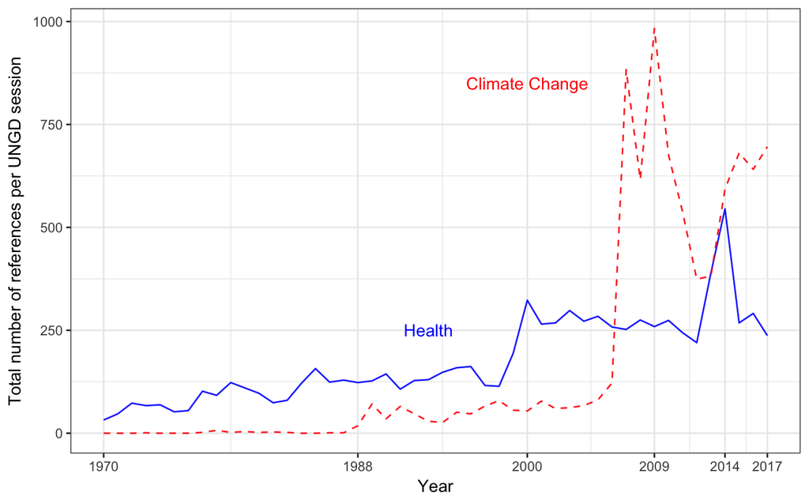

```r
# calculating the total number of mentions by year
sum <- summarise(group_by(intersection, year), count = sum(climate), mean = mean(climate))
sum_PHCC <- summarise(group_by(PHCC_counts, year),
                 count_CC = sum(CC), count_PH = sum(PH),
                 mean_CC = mean(CC), mean_PH = mean(PH))
sum_overall <- left_join(sum_PHCC, sum, by = "year")
#two observations for South Yemen republic are dropped. Zero mentions.
#Dropped due to bad conversion of ISO-Year document ID above, Country code is 4apha rather than 3.
ggplot(sum_overall, aes(x=year)) +
  theme_bw() +
  geom_line(aes(y= count_PH), colour = "blue", alpha = 0.9) +
  geom_line(aes(y= count_CC), colour = "red", alpha = 0.9, linetype="dashed") +
#  geom_line(aes(y= count), colour = "black", alpha = 0.9) +
  #ggtitle("Political engagement with the intersection of climate change and health") +
  ylab("Total number of references per UNGD session") + xlab("Year") +
#  scale_y_continuous(limits=c(0, 140), breaks = c(1, 50, 100, 134)) +
  scale_x_continuous(limits=c(1970, 2017), breaks = c(1970, 1988, 2000, 2009,2014, 2017)) +
 annotate("text", x = 2000, y = 850, label = "Climate Change", colour = "red")+
  annotate("text", x = 1993, y = 250, label = "Health", colour = "blue")
ggsave("timeseries_PHCC.pdf")
```

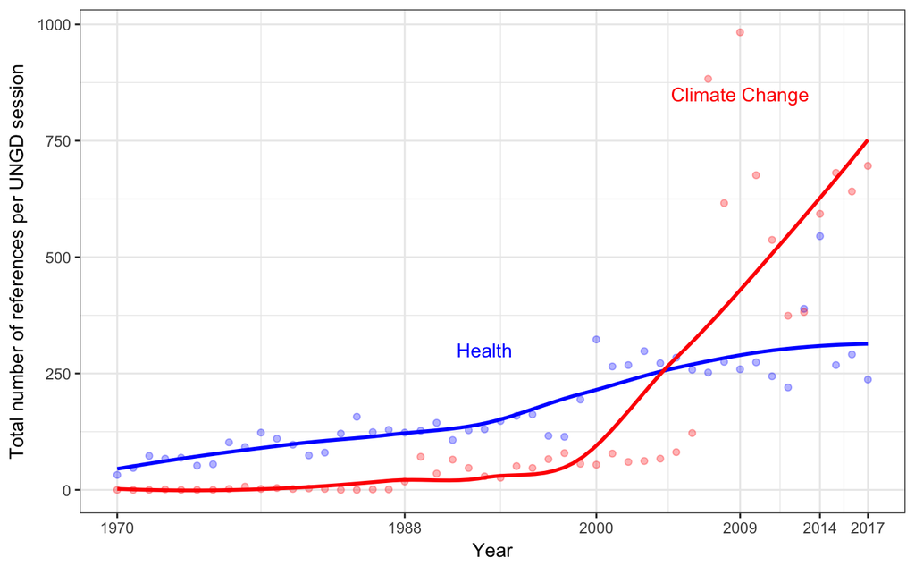

```r
ggplot(sum_overall, aes(x=year)) +
  theme_bw() +
  geom_point(aes(y= count_PH), colour = "blue", alpha = 0.3) +
  geom_smooth(aes(y= count_PH), colour = "blue", alpha = 0.5, se = FALSE) +
  geom_point(aes(y= count_CC), colour = "red", alpha = 0.3) +
    geom_smooth(aes(y= count_CC), colour = "red", alpha = 0.5, se = FALSE) +
#  geom_line(aes(y= count), colour = "black", alpha = 0.9) +
  #ggtitle("Political engagement with the intersection of climate change and health") +
  ylab("Total number of references per UNGD session") + xlab("Year") +
#  scale_y_continuous(limits=c(0, 140), breaks = c(1, 50, 100, 134)) +
  scale_x_continuous(limits=c(1970, 2017), breaks = c(1970, 1988, 2000, 2009,2014, 2017)) +
 annotate("text", x = 2009, y = 850, label = "Climate Change", colour = "red")+
  annotate("text", x = 1993, y = 300, label = "Health", colour = "blue")
ggsave("timeseries_PHCC_smoothed.pdf")
```

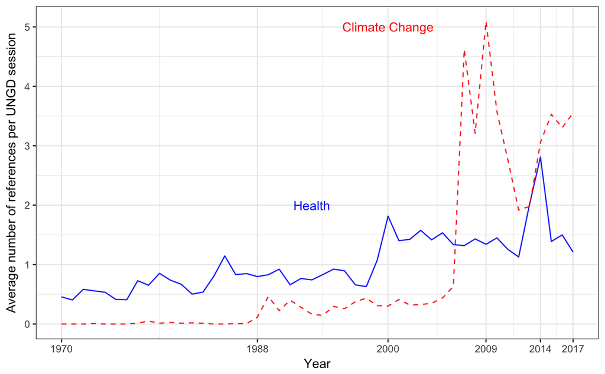

```r
ggplot(sum_overall, aes(x=year)) +
  theme_bw() +
  geom_line(aes(y= mean_PH), colour = "blue", alpha = 0.9) +
  geom_line(aes(y= mean_CC), colour = "red", alpha = 0.9, linetype="dashed") +
#  geom_line(aes(y= mean), colour = "black", alpha = 0.9) +
  #ggtitle("Political engagement with the intersection of climate change and health") +
  ylab("Average number of references per UNGD session") + xlab("Year") +
#  scale_y_continuous(limits=c(0, 140), breaks = c(1, 50, 100, 134)) +
  scale_x_continuous(limits=c(1970, 2017), breaks = c(1970, 1988, 2000, 2009,2014, 2017)) +
 annotate("text", x = 2000, y = 5, label = "Climate Change", colour = "red")+
  annotate("text", x = 1993, y = 2, label = "Health", colour = "blue")
ggsave("timeseries_PHCC_mean.pdf")
```

```r
ggplot(sum_overall, aes(x=year)) +
  theme_bw() +
  geom_point(aes(y= mean_PH), colour = "blue", alpha = 0.3) +
  geom_smooth(aes(y= mean_PH), colour = "blue", alpha = 0.2, color = alpha("blue", 0.1), se = FALSE) +
  geom_point(aes(y= mean_CC), colour = "red", alpha = 0.3) +
  geom_smooth(aes(y= mean_CC), colour = "red", alpha = 0.2, color = alpha("red", 0.1), se = FALSE) +
#  geom_line(aes(y= mean), colour = "black", alpha = 0.9) +
  #ggtitle("Political engagement with the intersection of climate change and health") +
  ylab("Average number of references per UNGD session") + xlab("Year") +
#  scale_y_continuous(limits=c(0, 140), breaks = c(1, 50, 100, 134)) +
  scale_x_continuous(limits=c(1970, 2017), breaks = c(1970, 1988, 2000, 2009,2014, 2017)) +
 annotate("text", x = 2000, y = 5, label = "Climate Change", colour = "red")+
  annotate("text", x = 1993, y = 2, label = "Health", colour = "blue")
```

```
The plyr::rename operation has created duplicates for the following name(s): (`colour`)The plyr::rename operation has created duplicates for the following name(s): (`colour`)
```

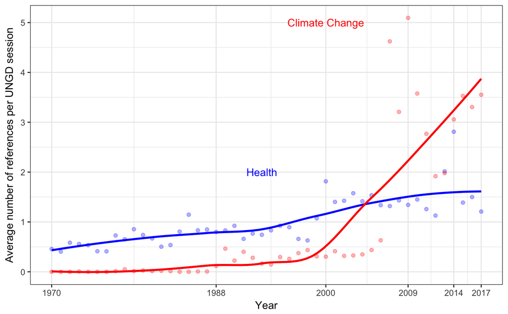

```r
ggsave("timeseries_PHCC_mean_smoothed.pdf")
```

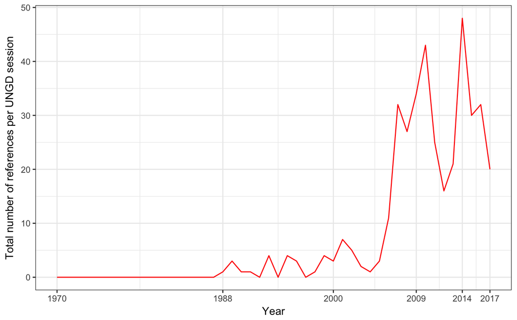

```r
ggplot(sum_overall, aes(x=year, y=count, group = 1)) +
  geom_line(colour="red", size=0.5) +
  theme_bw() +
  #ggtitle("Political engagement with the intersection of climate change and health") +
  ylab("Total number of references per UNGD session") + xlab("Year") +
#  scale_y_continuous(limits=c(0, 140), breaks = c(1, 50, 100, 134)) +
  scale_x_continuous(limits=c(1970, 2017), breaks = c(1970, 1988, 2000, 2009,2014, 2017))
  ggsave("intersection_25.pdf")
```

```r
ggplot(sum_overall, aes(x=year, y=count, group = 1)) +
  geom_point(colour="red", alpha = 0.3) +
  geom_smooth(aes(y= count), colour = "red", alpha = 0.2, color = alpha("red", 0.1), se = FALSE) +
  theme_bw() +
  #ggtitle("Political engagement with the intersection of climate change and health") +
  ylab("Total number of references per UNGD session") + xlab("Year") +
#  scale_y_continuous(limits=c(0, 140), breaks = c(1, 50, 100, 134)) +
  scale_x_continuous(limits=c(1970, 2017), breaks = c(1970, 1988, 2000, 2009,2014, 2017))
```

```
The plyr::rename operation has created duplicates for the following name(s): (`colour`)
```

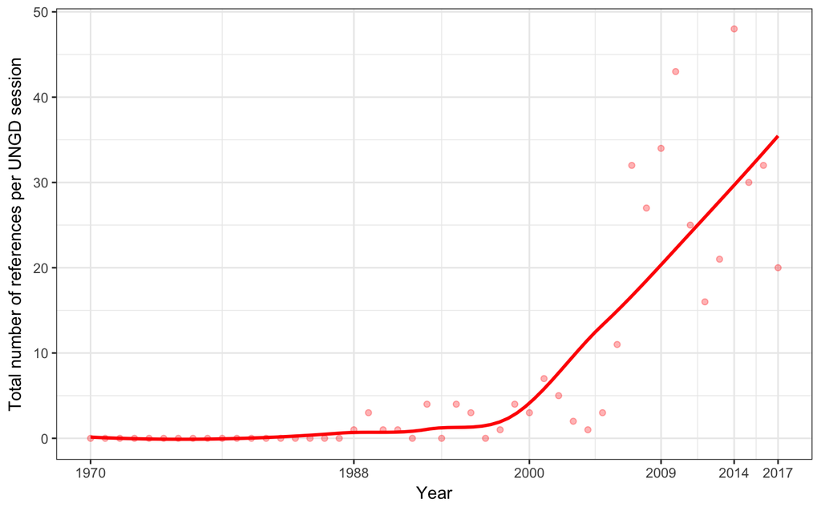

```r
  ggsave("intersection_25_smoothed.pdf")
```

## Total counts by WHO region

Using UN M49 Standard (Standard country or area codes for statistical use (M49)) we create regional and sub-regional groupings of countries. [https://unstats.un.org/unsd/methodology/m49/]

```r
#loading WHO regions country identifiers and preprocessing
regions <- read.csv("UNSD - Methodology.csv")
regions$ISO.alpha3.Code <- as.character(regions$ISO.alpha3.Code)
regions$Region.Name <- as.character(regions$Region.Name)
regions$Sub.region.Name <- as.character(regions$Sub.region.Name)
regions$WHO <- as.character(regions$WHO)
#UNGDC used YUG designation while WHO is using SRB
intersection$country <- str_replace(intersection$country, "YUG", "SRB")
PHCC_counts$country <- str_replace(PHCC_counts$country, "YUG", "SRB")
#merging WHO designations with mention counts
regional_data <- inner_join(PHCC_counts, regions, by = c("country" = "ISO.alpha3.Code"))
regional_data <- left_join(regional_data, intersection, by = c("country", "year"))
#replacing NAs with zeros
regional_data["climate"][is.na(regional_data["climate"])] <- 0
# total sum of mention counts by year and WHO region, with means
reg_sum <- summarise(group_by(regional_data, year, WHO),
                     count = sum(climate), mean = mean(climate),
                     count_PH = sum(PH), mean_PH = mean(PH),
                     count_CC = sum(CC), mean_CC = mean(CC))
```

Plot by region

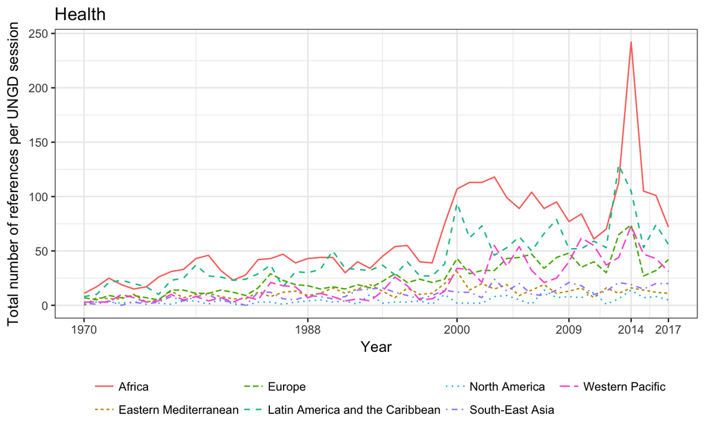

```r
ggplot(reg_sum, aes(x=year, y=count_PH, group=WHO, linetype = WHO, colour = WHO)) +
    geom_line() +
  guides(colour=guide_legend(title=NULL), linetype = FALSE) +
 guides(linetype=guide_legend(title=NULL)) +
  theme_bw() +
  ggtitle("Health") +
  ylab("Total number of references per UNGD session") + xlab("Year") +
  theme(legend.position="bottom") +
  scale_x_continuous(limits=c(1970, 2017), breaks = c(1970, 1988, 2000, 2009,2014, 2017))
  ggsave("PH_by_region.pdf")
```

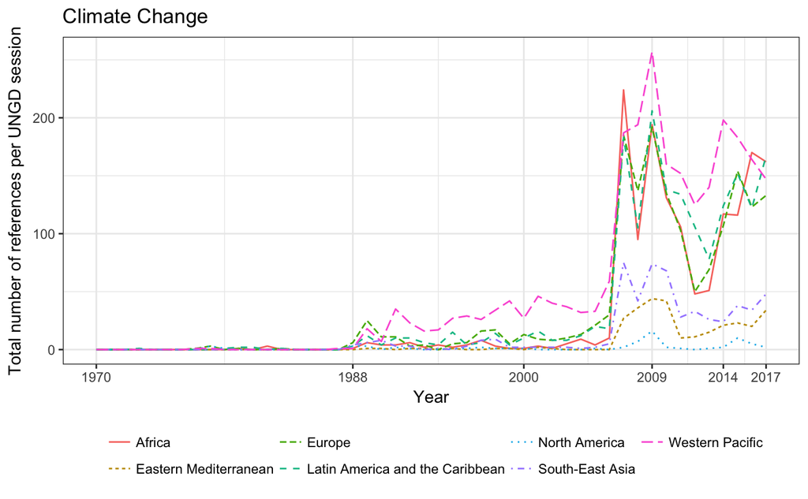

```r
ggplot(reg_sum, aes(x=year, y=count_CC, group=WHO, linetype = WHO, colour = WHO)) +
    geom_line() +
  guides(colour=guide_legend(title=NULL), linetype = FALSE) +
 guides(linetype=guide_legend(title=NULL)) +
  theme_bw() +
  ggtitle("Climate Change") +
  ylab("Total number of references per UNGD session") + xlab("Year") +
  theme(legend.position="bottom") +
  scale_x_continuous(limits=c(1970, 2017), breaks = c(1970, 1988, 2000, 2009,2014, 2017))
 ggsave("CC_by_region.pdf")
```

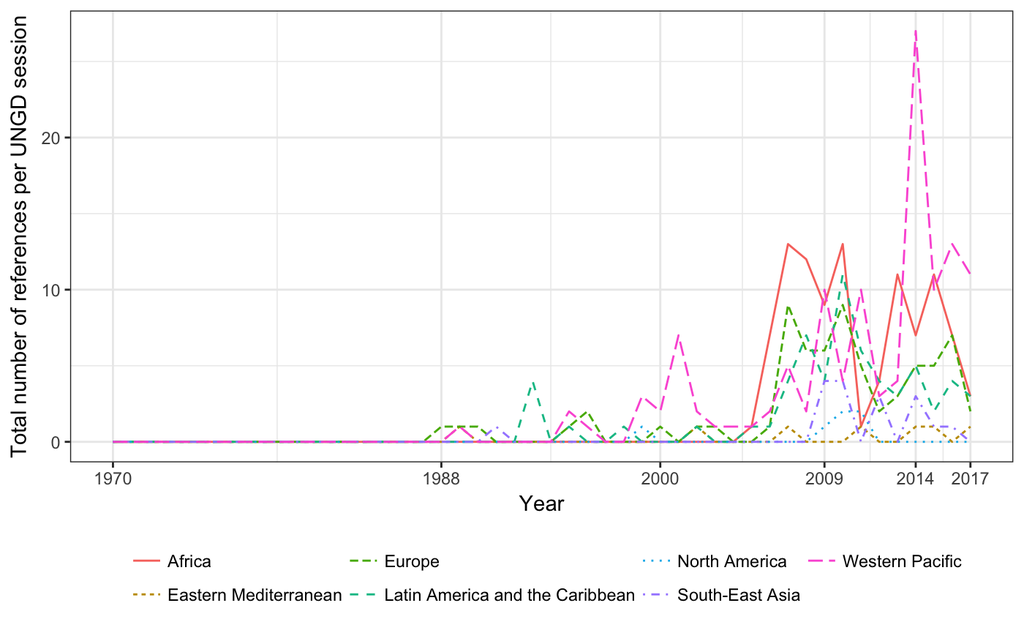

```r
ggplot(reg_sum, aes(x=year, y=count, group=WHO, linetype = WHO, colour = WHO)) +
    geom_line() +
  guides(colour=guide_legend(title=NULL), linetype = FALSE) +
 guides(linetype=guide_legend(title=NULL)) +
  theme_bw() +
#  ggtitle("Political engagement with the intersection of climate change and health") +
  ylab("Total number of references per UNGD session") + xlab("Year") +
  theme(legend.position="bottom") +
  scale_x_continuous(limits=c(1970, 2017), breaks = c(1970, 1988, 2000, 2009,2014, 2017))
  ggsave("intersection_by_region_25.pdf")
```

# Proportion of countries plots

Proportion of countries that had at least one mention

## Proportion for all countries

Data preparation

```r
#number of countries with a mention (any number)
mentions_annual <- summarise(group_by(mentions, year), numerator = n())
mentions_annual_CC <- summarise(group_by(mentions_CC, year), numerator_CC = n())
mentions_annual_PH <- summarise(group_by(mentions_PH, year), numerator_PH = n())
#total number of countries delivering a speech at UNGD per year
all_annual <- summarise(group_by(ungd_files, Year), denominator = n())
#merging numerator and denominator
all_speeches <- left_join(all_annual, mentions_annual_CC, by = c("Year"="year"))
all_speeches <- left_join(all_speeches, mentions_annual_PH, by = c("Year"="year"))
all_speeches <- left_join(all_speeches, mentions_annual, by = c("Year"="year"))
#replacing NAs with zeros
all_speeches["numerator"][is.na(all_speeches["numerator"])] <- 0
all_speeches["numerator_CC"][is.na(all_speeches["numerator_CC"])] <- 0
all_speeches["numerator_PH"][is.na(all_speeches["numerator_PH"])] <- 0
# percentage of countries per year with at least one mention of CC in PH context
all_speeches$percent <- all_speeches$numerator/all_speeches$denominator*100
all_speeches$percent_CC <- all_speeches$numerator_CC/all_speeches$denominator*100
all_speeches$percent_PH <- all_speeches$numerator_PH/all_speeches$denominator*100
```

Plotting the country proportion

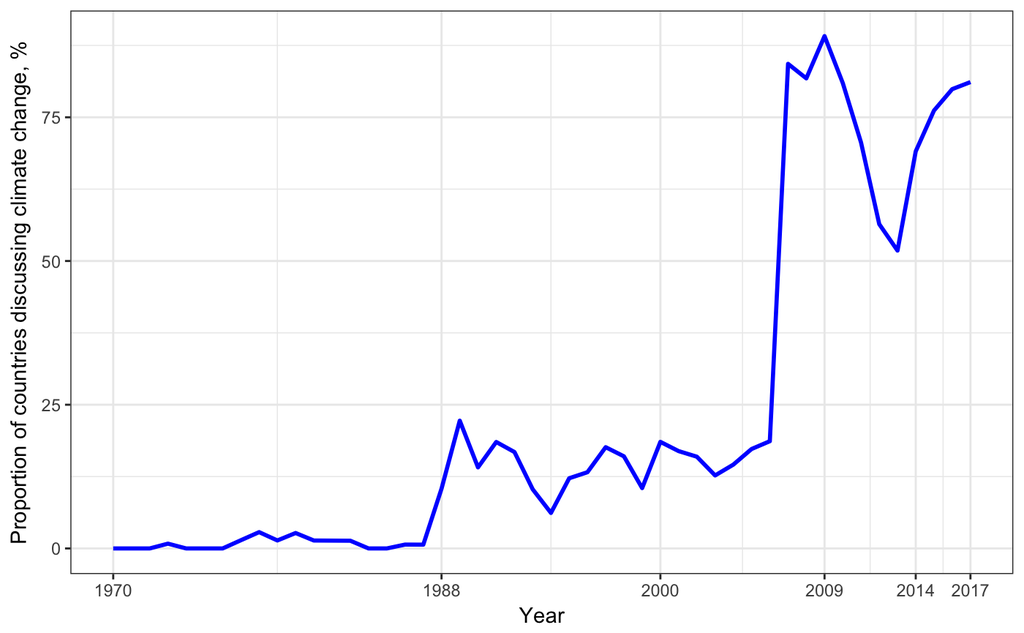

```r
ggplot(all_speeches, aes(x=Year, y=percent_CC, group = 1)) +
  geom_line(colour="blue", size=1) +
  theme_bw() +
  #ggtitle("Political engagement with the intersection of climate change and health") +
  ylab("Proportion of countries discussing climate change, %") + xlab("Year") +
  scale_x_continuous(limits=c(1970, 2017), breaks = c(1970, 1988, 2000, 2009,2014, 2017))
 ggsave("total_percent_CC.pdf")
```

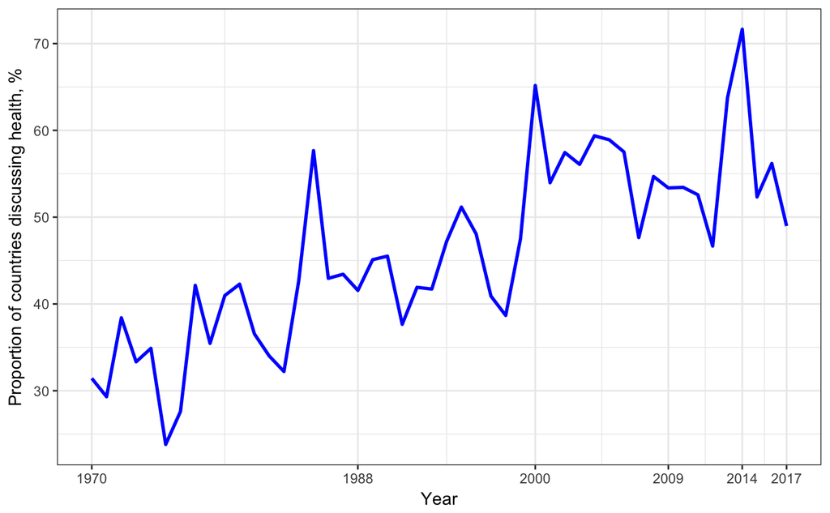

```r
ggplot(all_speeches, aes(x=Year, y=percent_PH, group = 1)) +
  geom_line(colour="blue", size=1) +
  theme_bw() +
  #ggtitle("Political engagement with the intersection of climate change and health") +
  ylab("Proportion of countries discussing health, %") + xlab("Year") +
  scale_x_continuous(limits=c(1970, 2017), breaks = c(1970, 1988, 2000, 2009,2014, 2017))
  ggsave("total_percent_PH.pdf")
```

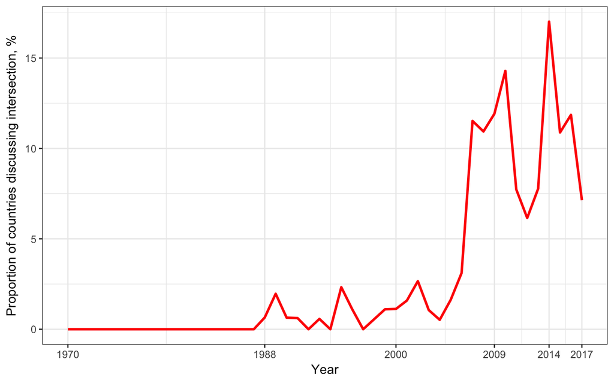

```r
ggplot(all_speeches, aes(x=Year, y=percent, group = 1)) +
  geom_line(colour="red", size=1) +
  theme_bw() +
  #ggtitle("Political engagement with the intersection of climate change and health") +
  ylab("Proportion of countries discussing intersection, %") + xlab("Year") +
  scale_x_continuous(limits=c(1970, 2017), breaks = c(1970, 1988, 2000, 2009,2014, 2017))
  ggsave("total_percent_25.pdf")
```

### all three

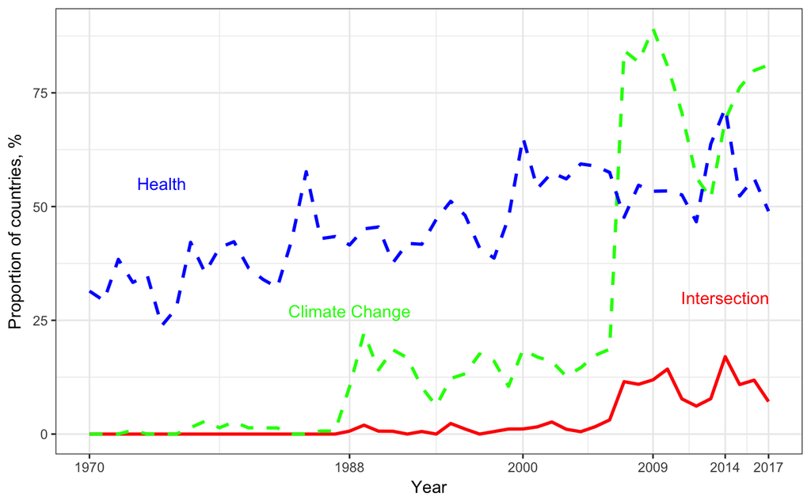

```r
ggplot(all_speeches, aes(x=Year)) +
  geom_line(aes(y=percent), colour="red", size=1) +
  geom_line(aes(y=percent_CC), colour="green", linetype = "dashed", size=1) +
  geom_line(aes(y=percent_PH), colour="blue", linetype = "dashed", size=1) +
  theme_bw() +
  #ggtitle("Political engagement with the intersection of climate change and health") +
  ylab("Proportion of countries, %") + xlab("Year") +
  scale_x_continuous(limits=c(1970, 2017), breaks = c(1970, 1988, 2000, 2009,2014, 2017))+
 annotate("text", x = 2014, y = 30, label = "Intersection", colour = "red")+
  annotate("text", x = 1975, y = 55, label = "Health", colour = "blue") +
  annotate("text", x = 1988, y = 27, label = "Climate Change", colour = "green")
  ggsave("all_three_percent_25.pdf")
```

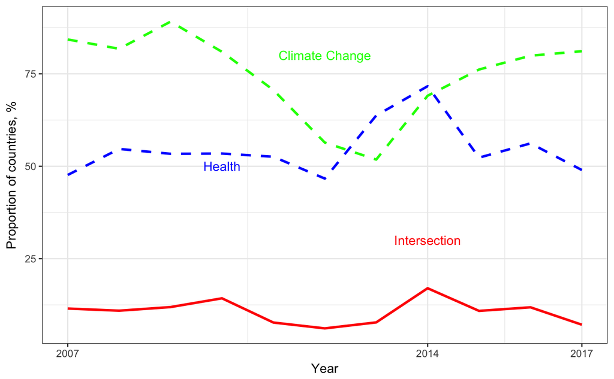

```r
ggplot(filter(all_speeches, Year>2006), aes(x=Year)) +
  geom_line(aes(y=percent), colour="red", size=1) +
  geom_line(aes(y=percent_CC), colour="green", linetype = "dashed", size=1) +
  geom_line(aes(y=percent_PH), colour="blue", linetype = "dashed", size=1) +
  theme_bw() +
  #ggtitle("Political engagement with the intersection of climate change and health") +
  ylab("Proportion of countries, %") + xlab("Year") +
  scale_x_continuous(limits=c(2007, 2017), breaks = c(2007,2014, 2017))+
 annotate("text", x = 2014, y = 30, label = "Intersection", colour = "red")+
  annotate("text", x = 2010, y = 50, label = "Health", colour = "blue") +
  annotate("text", x = 2012, y = 80, label = "Climate Change", colour = "green")
  ggsave("all_three_percent_25_2007.pdf")
```

## Proportion by WHO region

Data preparation

```r
mentions.regional <- subset(regional_data, climate!=0)
#number of countries with at least one mention by WHO region and year
mentions_climate_regional <- summarise(group_by(mentions.regional, year, WHO), numerator = n())
PH.regional <- subset(regional_data, PH!=0)
#number of countries with at least one mention by WHO region and year
mentions_PH_regional <- summarise(group_by(PH.regional, year, WHO), numerator_PH = n())
CC.regional <- subset(regional_data, CC!=0)
#number of countries with at least one mention by WHO region and year
mentions_CC_regional <- summarise(group_by(CC.regional, year, WHO), numerator_CC = n())
ungd_files$Country <- str_replace(ungd_files$Country, "YUG", "SRB")
# getting WHO region designations to all countries who gave a speech in UNGD
all_regional <- inner_join(ungd_files, regions, by = c("Country" = "ISO.alpha3.Code"))
# calculating total number of countries by year and WHO region who gave a speech in UNGD
all_reg_annual <- summarise(group_by(all_regional, Year, WHO), denominator = n())
# merging numerator and denominator
all_reginal_speeches <- left_join(all_reg_annual, mentions_PH_regional, by = c("Year"="year", "WHO"))
all_reginal_speeches <- left_join(all_reginal_speeches, mentions_CC_regional, by = c("Year"="year", "WHO"))
all_reginal_speeches <- left_join(all_reginal_speeches, mentions_climate_regional, by = c("Year"="year", "WHO"))
# replacing NAs with 0s
all_reginal_speeches["numerator"][is.na(all_reginal_speeches["numerator"])] <- 0
all_reginal_speeches["numerator_PH"][is.na(all_reginal_speeches["numerator_PH"])] <- 0
all_reginal_speeches["numerator_CC"][is.na(all_reginal_speeches["numerator_CC"])] <- 0
# calculating the percentage of countries with any mention of CC in PH context by WHO region and year
all_reginal_speeches$percent <- all_reginal_speeches$numerator/all_reginal_speeches$denominator*100
all_reginal_speeches$percent_PH <- all_reginal_speeches$numerator_PH/all_reginal_speeches$denominator*100
all_reginal_speeches$percent_CC <- all_reginal_speeches$numerator_CC/all_reginal_speeches$denominator*100
```

Plotting

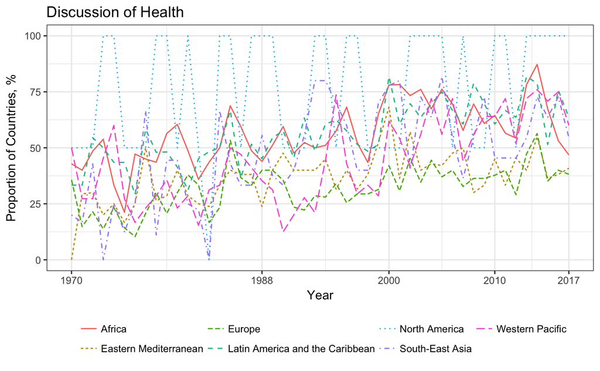

```r
ggplot(all_reginal_speeches, aes(x=Year, y=percent_PH, group=WHO, linetype = WHO, colour = WHO)) +
    geom_line() +
  guides(colour=guide_legend(title=NULL), linetype = FALSE) +
 guides(linetype=guide_legend(title=NULL)) +
  theme_bw() +
  ggtitle("Discussion of Health") +
  ylab("Proportion of Countries, %") + xlab("Year") +
  theme(legend.position="bottom") +
  scale_x_continuous(limits=c(1970, 2017), breaks = c(1970, 1988, 2000, 2010, 2017))
  ggsave("PH_percent_by_region.pdf")
```

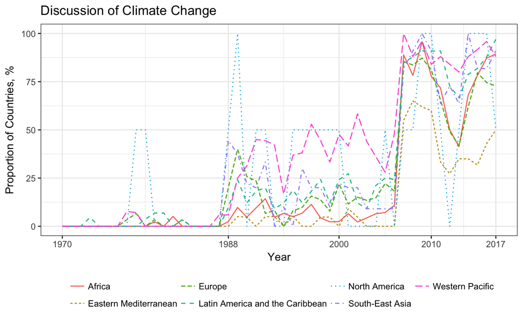

```r
ggplot(all_reginal_speeches, aes(x=Year, y=percent_CC, group=WHO, linetype = WHO, colour = WHO)) +
    geom_line() +
  guides(colour=guide_legend(title=NULL), linetype = FALSE) +
 guides(linetype=guide_legend(title=NULL)) +
  theme_bw() +
 ggtitle("Discussion of Climate Change") +
  ylab("Proportion of Countries, %") + xlab("Year") +
  theme(legend.position="bottom") +
  scale_x_continuous(limits=c(1970, 2017), breaks = c(1970, 1988, 2000, 2010, 2017))
  ggsave("CC_percent_by_region.pdf")
```

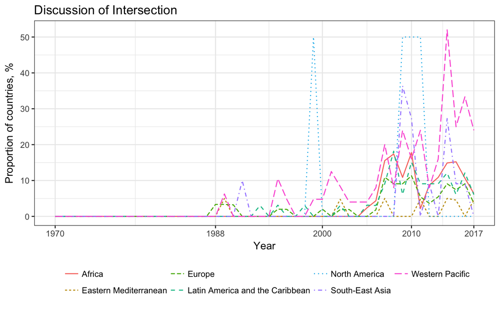

```r
ggplot(all_reginal_speeches, aes(x=Year, y=percent, group=WHO, linetype = WHO, colour = WHO)) +
    geom_line() +
  guides(colour=guide_legend(title=NULL), linetype = FALSE) +
 guides(linetype=guide_legend(title=NULL)) +
  theme_bw() +
  ggtitle("Discussion of Intersection") +
  ylab("Proportion of countries, %") + xlab("Year") +
  theme(legend.position="bottom") +
  scale_x_continuous(limits=c(1970, 2017), breaks = c(1970, 1988, 2000, 2010, 2017))
  ggsave("percent_by_region_25.pdf")
```